# CONFERENCIARECEBIMENTOCOLETOR

- > Treinamento Conferentes.

**RECEBIMENTO DE CARGA POR PRODUTO/PALETE NO COLETOR.**

> **Passo 1**. Login no coletor, insira o código e aperte “entrar”.

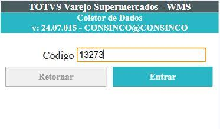

**Passo 2.** No menu principal aperte em Recebimento.

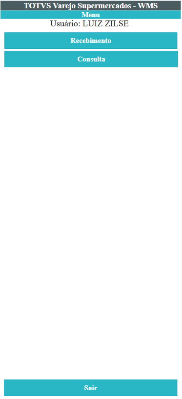

**Passo 3.** Clique em “Produto/Palete” para dar início a conferência via produto, ou seja, quando o conferente inicia a conferência direto na carga bipando os produtos.

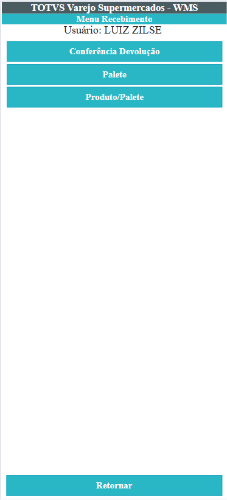

**PASSO 4**. Para dar início a conferência, realize a bipagem do EAN do produto ou digite o número do produto conforme destaque da imagem.

Caso o produto esteja em mais de uma carga, as cargas vão aparecer na tela para você selecionar qual vai ser conferida e clique em cima da carga.

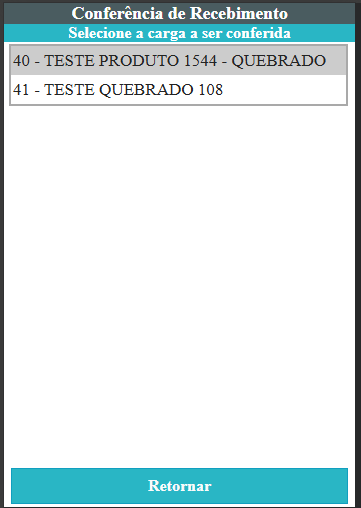

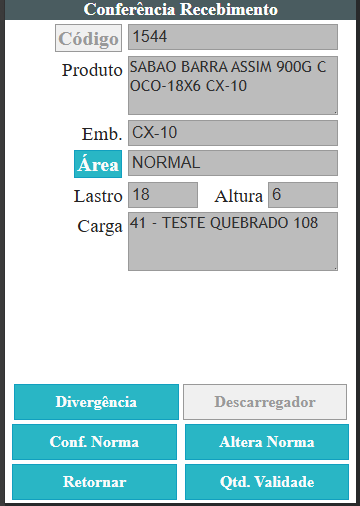

**PASSO 5**. Realize a bipagem da embalagem do produto que está sendo recebido ou digite o código do mesmo. Confira se o lastro e a altura estão de acordo com a contagem dos produtos, caso esteja conforme a norma clique no botão “Conf. Norma”.

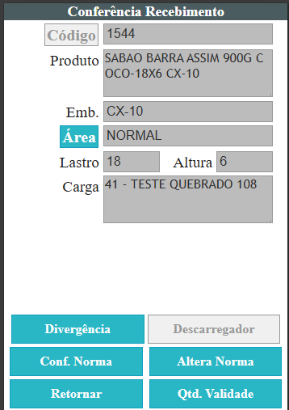

**OBS:** Em caso de divergência do físico com a norma do sistema clique em “Altera Norma”, e digite o lastro e altura corretos. Lembrando que o valor do campo “Lastro” sempre será multiplicado pela altura. O campo “Sobra” será sempre “0”, em seguida o sistema abrirá uma tela questionando se a conferência será feita fora da norma padrão, clique em “Sim” e por último digite a validade do produto.

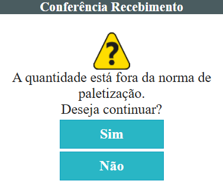

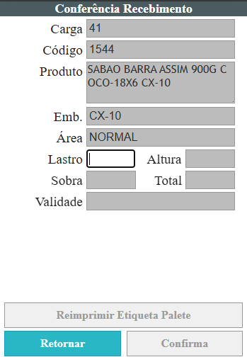

**PASSO 6.** Digite a validade do produto e tecle “Enter” no coletor. A tela 1 mostra que a validade digitada está à 70% da quantidade de dias do vencimento cadastrado no sistema, caso ocorra basta clicar em “Sim” e seguir com a conferência. Na tela 2, a validade digitada está à 30% da quantidade de dias cadastrados no sistema, por isso, neste caso só será possível seguir com a conferência com autorização da gerência, conforme tela 3.

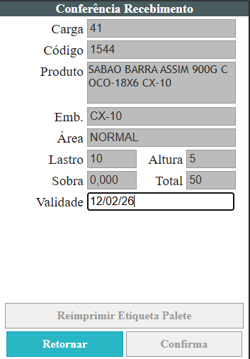

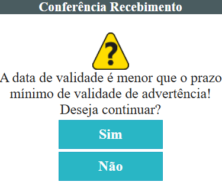

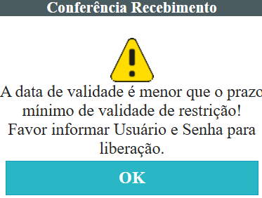

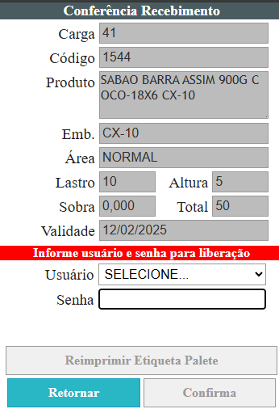

**PASSO 7.** Selecione a opção para impressão da etiqueta de conferência.

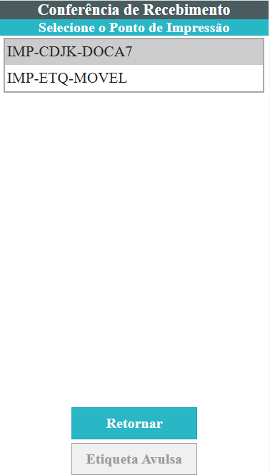

[figure not shown]

**PASSO 8**. Digite o número do palete que está na etiqueta que foi impressa para validar a conferência e clique em “Confirma” para finalizar a conferência do palete.

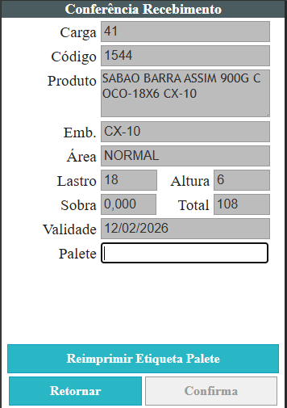

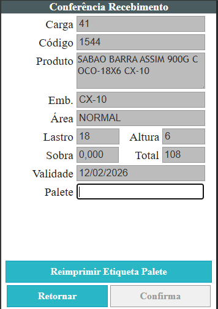

**Obs:** Ao final da conferência de cada página o sistema retornará para a tela inicial, o mesmo acontecerá quando toda a carga tiver sido conferida. Informe ao assistente de recebimento o término da conferência.

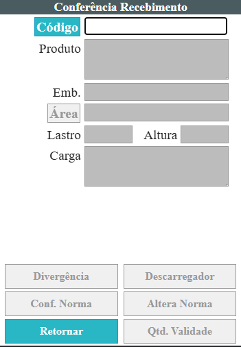

**OBS:** Caso haja erro na contagem basta realizar a bipagem da etiqueta novamente e reiniciar a conferência.

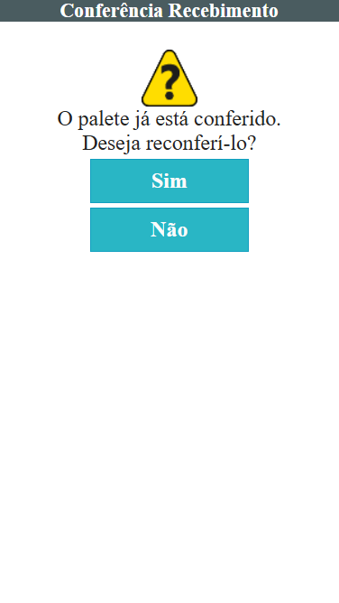

**CONFERÊNCIA VIA PALETE (ETIQUETAS IMPRESSAS ANTES DA CONFERÊNCIA)**

**Passo 1**. Clique em “Palete” para dar início a conferência via palete, ou seja, quando o conferente já estará com as etiquetas dos paletes em mãos.

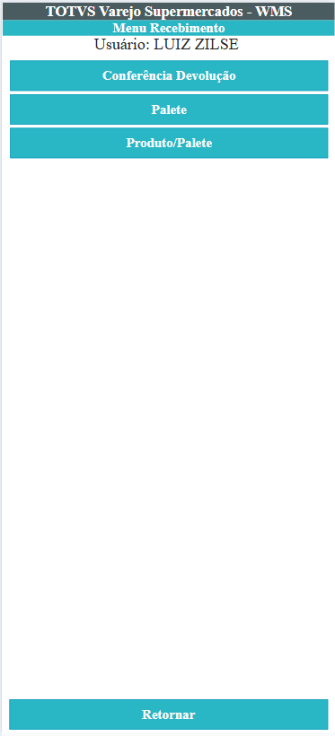

**PASSO 2**. Para dar início a conferência, realize a bipagem da etiqueta ou digite o número do palete conforme destaque da imagem.

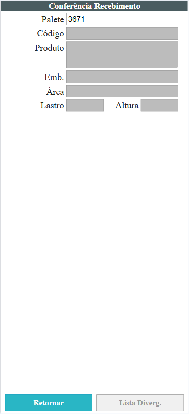

[figure not shown]

**PASSO 3**. Realize a bipagem da embalagem do produto que está sendo recebido ou digite o código do mesmo. Na sequência, ele deve bipar no código do produto. Confira se o lastro e a altura estão de acordo com a contagem dos produtos, caso esteja conforme a norma clique no botão “Conf. Norma”.

[figure not shown]

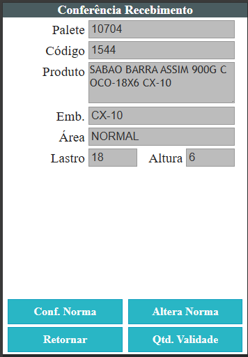

**OBS:** Em caso de divergência na conferência clique em “Altera Norma”, e digite o lastro e altura corretos. Lembrando que o valor do campo “Lastro” sempre será multiplicado pela altura. O campo “Sobra” será sempre “0”, e por último digite a validade do produto.

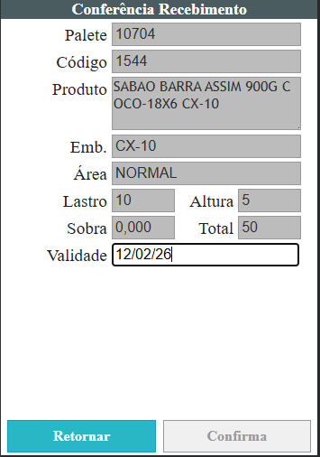

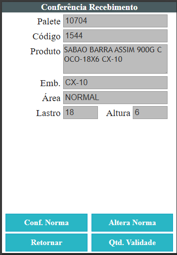

**OBS:** Caso haja erro na contagem basta realizar a bipagem da etiqueta novamente e reiniciar a conferência.

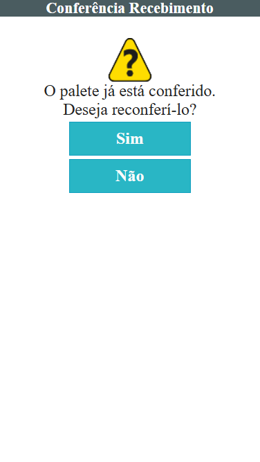

**PASSO 6**. Digite a validade do produto e tecle “Enter” no coletor. A tela 1 mostra que a validade digitada está à 70% da quantidade de dias do vencimento cadastrado no sistema, caso ocorra basta clicar em “Sim” e seguir com a conferência. Na tela 2, a validade digitada está à 30% da quantidade de dias cadastrados no sistema, por isso, neste caso só será possível seguir com a conferência com autorização da gerência, conforme tela 3.

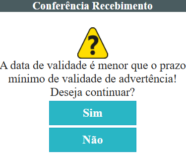

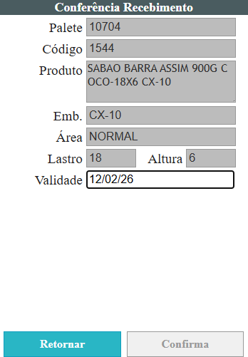

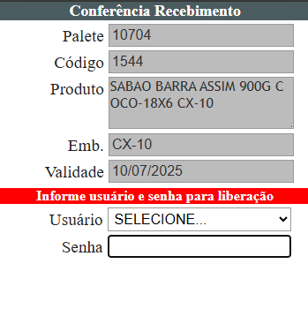

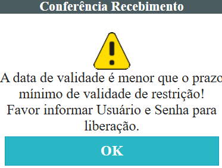

**PASSO 7**. Após a conferência de cada etiqueta, o sistema sempre retornará para a tela abaixo. Quando finalizar todas as etiquetas basta informar ao assistente de recebimento.

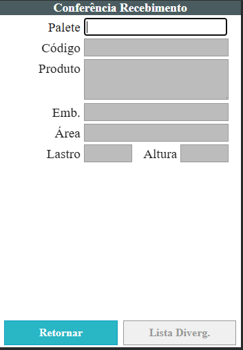